# DeepSig: Machine Learning-based Mutational Signature Inference for WES and MSK-IMPACT data

# 1 De novo inference

```r
library(DeepSig)
```

We illustrate de novo inferences using TCGA-BRCA catalog data:

```r
brca <- read.table(system.file('extdata', 'tcga_brca_mutect_catalog.txt',
                               package = 'DeepSig'))
tcga <- DeepSig(data = brca)
tcga
```

```
#> Class: DeepSig
#> Number of mutation types =  96
#>   [1] "A[C>A]A" "A[C>A]C" "A[C>A]G" "A[C>A]T" "C[C>A]A" "C[C>A]C"
#> Number of samples =  985
#> Number of signatures =  30
#>   [1] "Signature.1" "Signature.2" "Signature.3" "Signature.4" "Signature.5"
#> [6] "Signature.6"
```

## 1.1 Number of signatures

`DeepSig` provides a way to determine the most likely number $K$ of signatures present using a Bayesian marginal likelihood method. To do this, scan a range of $K$ values via

```r
set.seed(152)
tscan <- extractSig(tcga, method = 'bnmf', Kmin = 2, Kmax = 10, nrun = 10, progress.bar = TRUE)
```

```r
me <- misc(tscan)$measure
me
```

```
#>    K       LML
#> 1  2 -1.134082
#> 2  3 -1.062338
#> 3  4 -1.040996
#> 4  5 -1.036085
#> 5  6 -1.034881
#> 6  7 -1.034655
#> 7  8 -1.042157
#> 8  9 -1.043245
#> 9 10 -1.052176
```

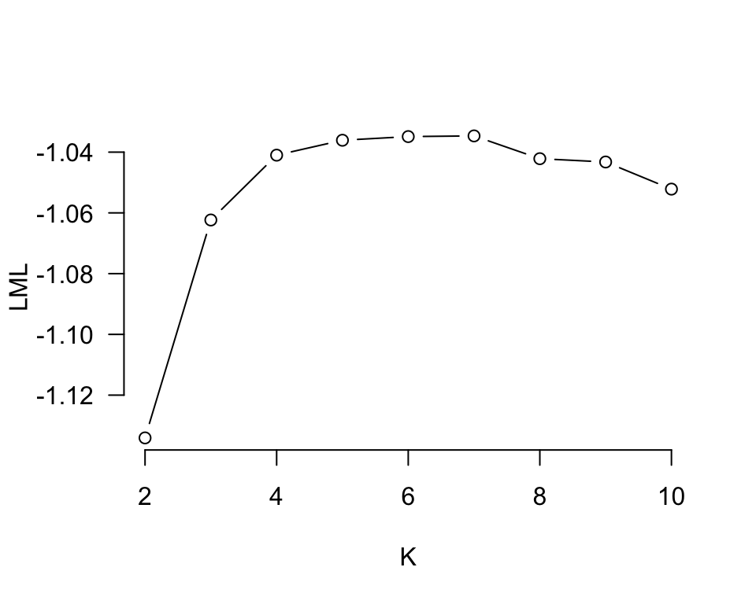

```r
plot(me, type = 'b', las = 1, bty = 'n')
```

Note that individual runs consist of $K$ values scanned from `Kmin` (default 2) to `Kmax`. Often, increasing the size of signature set by one will result in redundant signatures beyond a certain $K$ value. If this occurrs, the scan will stop and print this upper bound `Kmax`. In the example above, this upper bound is often smaller than the maximum 10.

## 1.2 Decomposition under optimal K

The LML (log marginal likelihood) plot above suggests a minimal $K = 5$. It is then recommended to re-run the de novo inference using `method = "nmf"` under `K = 5`:

```r
tcga <- extractSig(tcga, method = 'nmf', K = 5, nrun = 100, progress.bar = TRUE)
sig <- signat(tcga)
head(sig)
```

```
#>                  S1           S2           S3          S4           S5
#> A[C>A]A 0.022865850 0.0003978184 0.0001293209 0.006284554 8.052323e-04
#> A[C>A]C 0.026251346 0.0012807084 0.0018426426 0.008393485 5.987982e-04
#> A[C>A]G 0.008334722 0.0005781266 0.0001960372 0.003019926 1.267483e-04
#> A[C>A]T 0.017160340 0.0083219544 0.0020767408 0.002144325 5.991101e-09
#> C[C>A]A 0.029181471 0.0033832615 0.0084918547 0.001258732 1.295624e-03
#> C[C>A]C 0.020585416 0.0016095629 0.0174922820 0.001994169 7.338716e-04
```

## 1.3 Signature annotation

The main object of interest within `tcga` is the de novo signature set that can be extracted as `signat(tcga)`. We compute a cosine similarity matrix between de novo and reference signatures (COSMIC v3)

```r
cs <- denovoCosim(sig = sig, ref.sig = 'cosmic')
cs[,1:5]
```

```
#>          SBS1       SBS2      SBS3       SBS4      SBS5
#> S1 0.08901991 0.02025239 0.8935174 0.73309629 0.6224701
#> S2 0.26026850 0.11163952 0.1330729 0.20281120 0.2488961
#> S3 0.67184277 0.00889928 0.3979952 0.22758352 0.5792624
#> S4 0.82594489 0.32506863 0.2833679 0.13973907 0.5068363
#> S5 0.05212630 0.75443029 0.2713987 0.09488812 0.3074044
```

There is a customized heatmap for displaying `cs`:

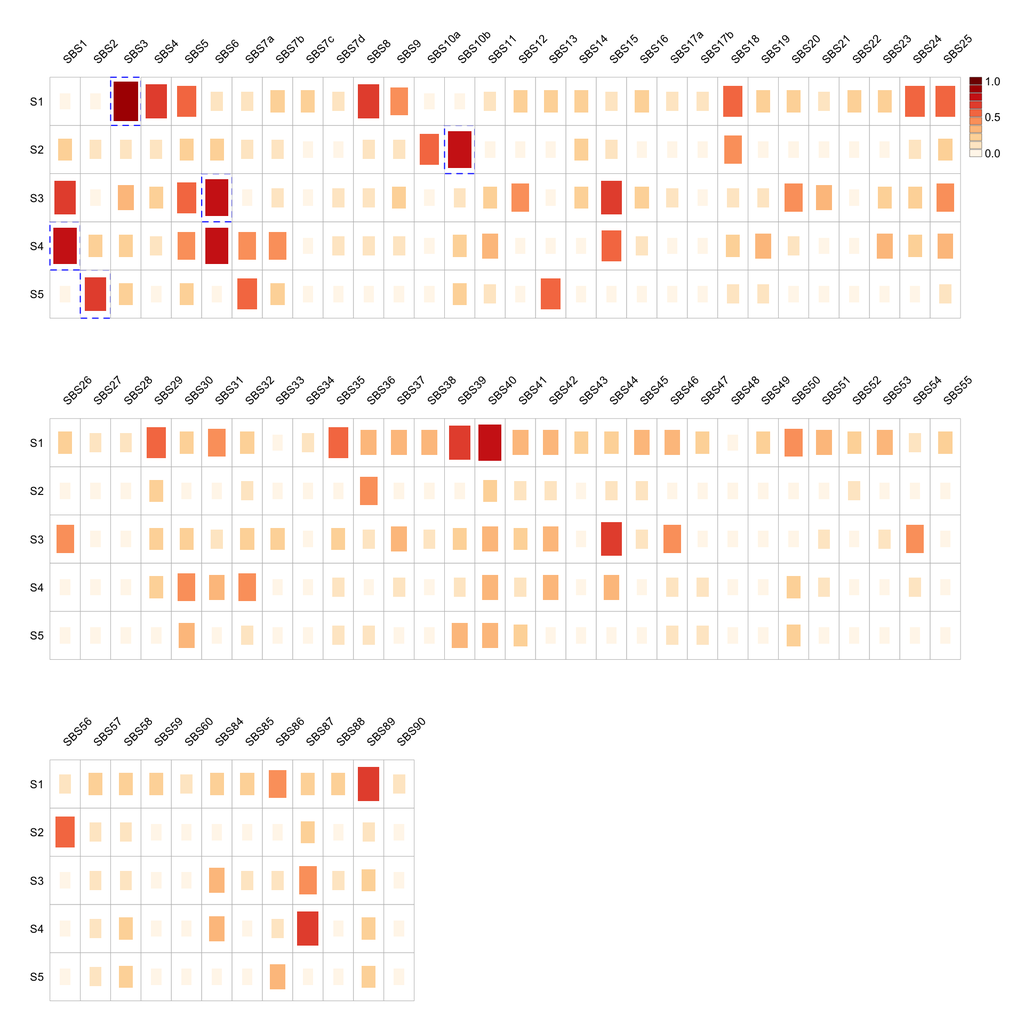

```r
csHeatmap(cs)
```

In the above, we computed the cosine similarity matrix of the 5 de novo signatures with the COSMIC v3 set. To aid annotation, an automated assignment from the linear sum assignment problem (LSAP) algorithm is available (shown by default as blue rectangles in the heatmap above):

```r
sigLSAP(cs)
```

```
#>       S1       S2       S3       S4       S5
#>   "SBS3" "SBS10b"   "SBS6"   "SBS1"   "SBS2"
```

More often than not, this assignment may not be optimal and it is recommended that the user inspect the overlap distribution manually. The heatmap indicates that `S1-S5` correspond to SBS3 (HRD), SBS10 (POLE), SBS6 (MMR), SBS1(aging), and SBS2.13 (APOBEC), respectively.

To faciliate further analyses, it is convenient to re-label de novo signatures based on these annotations:

```r
annotation <- c('SBS_1'='S4','SBS_2.13'='S5','SBS_3'='S1','SBS_6'='S3','SBS_10'='S2')
tcga2 <- reorderSig(tcga, annotation = annotation)
head(signat(tcga2))
```

```
#>               SBS_1     SBS_2.13       SBS_3        SBS_6       SBS_10
#> A[C>A]A 0.006284554 8.052323e-04 0.022865850 0.0001293209 0.0003978184
#> A[C>A]C 0.008393485 5.987982e-04 0.026251346 0.0018426426 0.0012807084
#> A[C>A]G 0.003019926 1.267483e-04 0.008334722 0.0001960372 0.0005781266
#> A[C>A]T 0.002144325 5.991101e-09 0.017160340 0.0020767408 0.0083219544
#> C[C>A]A 0.001258732 1.295624e-03 0.029181471 0.0084918547 0.0033832615
#> C[C>A]C 0.001994169 7.338716e-04 0.020585416 0.0174922820 0.0016095629
```

The function `reorderSig` reorders the signatures of the object in the sequence of `annotation` parameter and renames them according to `names(annotation)`.

We now examine the actual shape simlarity of de novo and reference signatures:

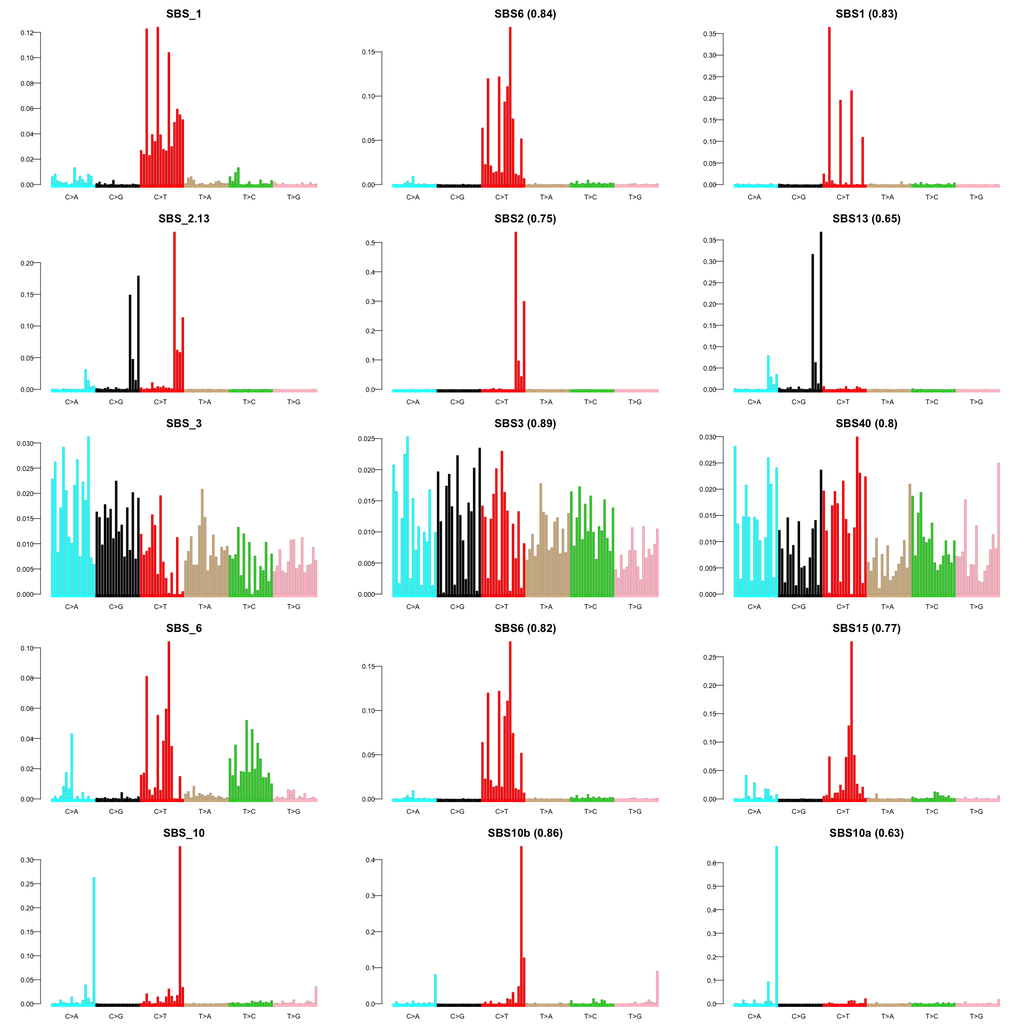

```r
denovoProfiles(tcga2, ref.sig = 'cosmic')
```

The left-most column shows de novo signatures and the second and third columns show the reference signatures with the top and second-highest cosine similarity overlaps (in parentheses) with de novo signatures. Note that `SBS_2` is in fact a composite of `SBS2` and `SBS13`, which is a very common occurence; the two APOBEC signatures rarely are seen separately in non-WGS samples. The same is true for `SBS_10`, which is a composite of `SBS10a` and `SBS10b`.